# Introducción a los motores

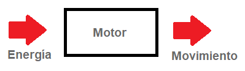

Un motor convierte energía en movimiento.

### 1. ¿Qué es un motor?

Un motor es un dispositivo que convierte algún tipo de energía en energía mecánica, es decir, en movimiento.

Por ejemplo un motor eléctrico convierte la energía eléctica en una rotación de un eje.

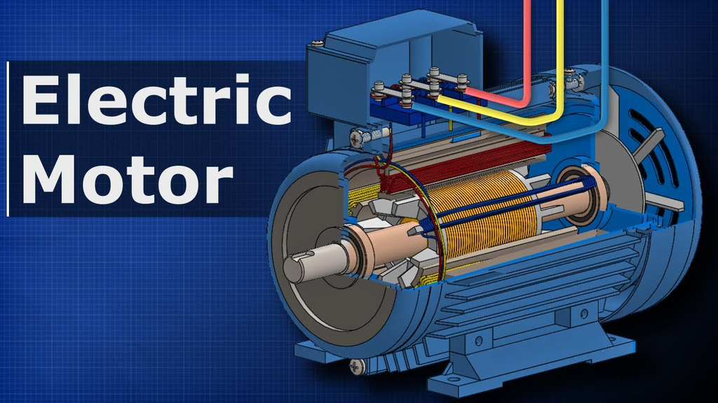

Existen muchos tipos de motores: motores a nafta o gasoil, turbinas, motores eléctricos, motores híbridos, etc.

### 2. Una primera noción del motor de dos tiempos (Alternancia 0)

El motor de dos tiempos es un motor de combustión interna que usa normalmente como combustible una mezcla de nafta y aceite que al quemarse (explotar) mueve un pistón dentro de un cilindro. Esto produce la rotación de un eje llamado cigueñal.

#### Actividad

Busca un esquema de un motor de dos tiempos y dibuja tu propia versión. Deben aparecer al menos las siguientes partes: cilindro, pistón, biela y lumbreras. Te conviene buscar y hacer un dibujo 2D (en dos dimensiones).

### 3. Clasificación de los motores (Alternancia 1)

**Según la fuente de energía**

Tiene que ver con: *¿de dónde saca el motor la energía que transforma en movimiento?*:

- **Térmico**: Combustible (nafta, gasoil, gas, etc.). Ej: Motor de un tractor
- **Eléctrico**: Electricidad. Ej: Motor de una bomba de agua eléctrica
- **Hidráulico**: Presión de un fluido. Ej: Motor hidráulico en una sembradora
- **Neumático**: Aire comprimido. Ej: Herramientas neumáticas
- **Motores híbridos**: Combinación (eléctrico + térmico). Ej: Algunos tractores modernos o autos

**Según el principio de funcionamiento**

Tiene que ver con *cómo transforman la energía internamente*:

- **Motores de combustión interna**: queman combustible dentro del propio motor (motores de explosión como el diésel, etc.).
- **Motores de combustión externa**: queman el combustible fuera del motor y usan el calor (como las turbinas de vapor).
- **Motores eléctricos**: convierten energía eléctrica en movimiento mediante campos magnéticos.
- **Motores hidráulicos y neumáticos**: funcionan por presión de fluidos.

#### Actividad

Buscar y escribir la definición de motor de combustión interna y de combustión externa. Luego agrupar los motores vistos en clase en una de estas dos categorías “siempre que corresponda”. Por ejemplo el motor eléctrico no corresponde a ninguna, el de 4T corresponde a “combustión interna”.